# DataFrames_and_Lists

HDS

2024-06-21

## Data Frames and Lists

A dataframe in R is pretty much an R version of an SQL data table

Modern computer languages borrow concepts from one another constantly.

Python has a library called Pandas that implements a dataframe in Python that works me in a very similar way.

In a dataframe (or SQL data table) each row is an “observation” or an “event” an “individual item”.

All the variable values on a given row belong to the same observation

The columns of a dataframe are different variables, one per column. The columns do not have to be the same type of data as the other columns.

Dataframes look much like Excel sheets, but the structure is more rigid.

Typically you will be loading a dataframe from some data source, maybe a database, a website or a table created in Excel.

Right now we will look at an example data set that comes with R the “Motor Trend cars” data set mtcars. This is a built in “lab rat” data set that comes with R

We will load the data first

```r
data(mtcars)
```

We can find out what is in it using STR

```r
str(mtcars)
```

```
## 'data.frame':    32 obs. of  11 variables:
##  $ mpg : num  21 21 22.8 21.4 18.7 18.1 14.3 24.4 22.8 19.2 ...
##  $ cyl : num  6 6 4 6 8 6 8 4 4 6 ...
##  $ disp: num  160 160 108 258 360 ...
##  $ hp  : num  110 110 93 110 175 105 245 62 95 123 ...
##  $ drat: num  3.9 3.9 3.85 3.08 3.15 2.76 3.21 3.69 3.92 3.92 ...
##  $ wt  : num  2.62 2.88 2.32 3.21 3.44 ...
##  $ qsec: num  16.5 17 18.6 19.4 17 ...
##  $ vs  : num  0 0 1 1 0 1 0 1 1 1 ...
##  $ am  : num  1 1 1 0 0 0 0 0 0 0 ...
##  $ gear: num  4 4 4 3 3 3 3 4 4 4 ...
##  $ carb: num  4 4 1 1 2 1 4 2 2 4 ...
```

Like a matrix, the data frame has rows and columns we can index by number

There are 32 rows here and 11 columns

We can look at the first 6 rows of the data frame, this is a nice way to see what is in a data frame

```r
head(mtcars)
```

```
##                    mpg cyl disp  hp drat    wt  qsec vs am gear carb
## Mazda RX4         21.0   6  160 110 3.90 2.620 16.46  0  1    4    4
## Mazda RX4 Wag     21.0   6  160 110 3.90 2.875 17.02  0  1    4    4
## Datsun 710        22.8   4  108  93 3.85 2.320 18.61  1  1    4    1
## Hornet 4 Drive    21.4   6  258 110 3.08 3.215 19.44  1  0    3    1
## Hornet Sportabout 18.7   8  360 175 3.15 3.440 17.02  0  0    3    2
## Valiant           18.1   6  225 105 2.76 3.460 20.22  1  0    3    1
```

We can see the last 6 lines using the tail() function, or the whole dataframe using the View() function

It is a bad idea to depend too heavily on the View() option.

This is a small data set, 32 rows by 11 columns, so it is easy to understand what is happening, but when you get into the hundreds or thousands of rows, View() is not really useful anymore

```r
#View(mtcars)
```

On the other hand, I use str(), head() and colnames() constantly

We can get lists of the row and column names

```r
rownames(mtcars)
```

```
##  [1] "Mazda RX4"           "Mazda RX4 Wag"       "Datsun 710"
##  [4] "Hornet 4 Drive"      "Hornet Sportabout"   "Valiant"
##  [7] "Duster 360"          "Merc 240D"           "Merc 230"
## [10] "Merc 280"            "Merc 280C"           "Merc 450SE"
## [13] "Merc 450SL"          "Merc 450SLC"         "Cadillac Fleetwood"
## [16] "Lincoln Continental" "Chrysler Imperial"   "Fiat 128"
## [19] "Honda Civic"         "Toyota Corolla"      "Toyota Corona"
## [22] "Dodge Challenger"    "AMC Javelin"         "Camaro Z28"
## [25] "Pontiac Firebird"    "Fiat X1-9"           "Porsche 914-2"
## [28] "Lotus Europa"        "Ford Pantera L"      "Ferrari Dino"
## [31] "Maserati Bora"       "Volvo 142E"
```

```r
colnames(mtcars)
```

```
##  [1] "mpg"  "cyl"  "disp" "hp"   "drat" "wt"   "qsec" "vs"   "am"   "gear"
## [11] "carb"
```

# Summary

Most R variables will show you some interesting information when you use the summary() function

```r
summary(mtcars)
```

```
##       mpg             cyl             disp             hp
##  Min.   :10.40   Min.   :4.000   Min.   : 71.1   Min.   : 52.0
##  1st Qu.:15.43   1st Qu.:4.000   1st Qu.:120.8   1st Qu.: 96.5
##  Median :19.20   Median :6.000   Median :196.3   Median :123.0
##  Mean   :20.09   Mean   :6.188   Mean   :230.7   Mean   :146.7
##  3rd Qu.:22.80   3rd Qu.:8.000   3rd Qu.:326.0   3rd Qu.:180.0
##  Max.   :33.90   Max.   :8.000   Max.   :472.0   Max.   :335.0
##       drat             wt             qsec             vs
##  Min.   :2.760   Min.   :1.513   Min.   :14.50   Min.   :0.0000
##  1st Qu.:3.080   1st Qu.:2.581   1st Qu.:16.89   1st Qu.:0.0000
##  Median :3.695   Median :3.325   Median :17.71   Median :0.0000
##  Mean   :3.597   Mean   :3.217   Mean   :17.85   Mean   :0.4375
##  3rd Qu.:3.920   3rd Qu.:3.610   3rd Qu.:18.90   3rd Qu.:1.0000
##  Max.   :4.930   Max.   :5.424   Max.   :22.90   Max.   :1.0000
##        am              gear            carb
##  Min.   :0.0000   Min.   :3.000   Min.   :1.000
##  1st Qu.:0.0000   1st Qu.:3.000   1st Qu.:2.000
##  Median :0.0000   Median :4.000   Median :2.000
##  Mean   :0.4062   Mean   :3.688   Mean   :2.812
##  3rd Qu.:1.0000   3rd Qu.:4.000   3rd Qu.:4.000
##  Max.   :1.0000   Max.   :5.000   Max.   :8.000
```

# Indexing a data frame

Indexing works the same way it does for matrices or vectors

Index with integers

```r
mtcars[1,1:5]
```

```
##           mpg cyl disp  hp drat
## Mazda RX4  21   6  160 110  3.9
```

```r
mtcars[2,]
```

```
##               mpg cyl disp  hp drat    wt  qsec vs am gear carb
## Mazda RX4 Wag  21   6  160 110  3.9 2.875 17.02  0  1    4    4
```

```r
mtcars[,10]
```

```
##  [1] 4 4 4 3 3 3 3 4 4 4 4 3 3 3 3 3 3 4 4 4 3 3 3 3 3 4 5 5 5 5 5 4
```

```r
mtcars["Mazda RX4","hp"]
```

```
## [1] 110
```

# Working with a column

We can work with a column by giving the name of the dataframe, $ and the column name

```r
mtcars$wt
```

```
##  [1] 2.620 2.875 2.320 3.215 3.440 3.460 3.570 3.190 3.150 3.440 3.440 4.070
## [13] 3.730 3.780 5.250 5.424 5.345 2.200 1.615 1.835 2.465 3.520 3.435 3.840
## [25] 3.845 1.935 2.140 1.513 3.170 2.770 3.570 2.780
```

# Adding a column

R does not “protect” data frames, we can just add a new column by giving it a column name and a set of values- this is a bit alarming if you are used to managing SQL databases :)

Example:

In cars, the horsepower to Weight ratio is important (it is for humans too)

We can add this variable to our data frame

```r
mtcars["Power_2_Weight"]=mtcars$hp/mtcars$wt
```

We can now ask, which car has the highest power to weight ratio?

```r
maxPW_index=which.max(mtcars$Power_2_Weight)

mtcars[maxPW_index,]
```

```
##               mpg cyl disp  hp drat   wt qsec vs am gear carb Power_2_Weight
## Maserati Bora  15   8  301 335 3.54 3.57 14.6  0  1    5    8       93.83754
```

It might be sort of interesting to see the top three power to weight vehicles, not just the largest.

We’d like to sort the data frame by Power_2_weight ratio

We use order to get the indexing to do this

```r
p2w_index=order(mtcars$Power_2_Weight,decreasing = TRUE)

head(mtcars[p2w_index,])
```

```
##                 mpg cyl  disp  hp drat    wt  qsec vs am gear carb
## Maserati Bora  15.0   8 301.0 335 3.54 3.570 14.60  0  1    5    8
## Ford Pantera L 15.8   8 351.0 264 4.22 3.170 14.50  0  1    5    4
## Lotus Europa   30.4   4  95.1 113 3.77 1.513 16.90  1  1    5    2
## Duster 360     14.3   8 360.0 245 3.21 3.570 15.84  0  0    3    4
## Camaro Z28     13.3   8 350.0 245 3.73 3.840 15.41  0  0    3    4
## Ferrari Dino   19.7   6 145.0 175 3.62 2.770 15.50  0  1    5    6
##                Power_2_Weight
## Maserati Bora        93.83754
## Ford Pantera L       83.28076
## Lotus Europa         74.68605
## Duster 360           68.62745
## Camaro Z28           63.80208
## Ferrari Dino         63.17690
```

Look at those ideas- think of how you might use them on your own problem to work with data

# Indexing, selecting and slicing

We can use this “matrix style” approach to selecting specific rows or columns or sections of data frames or matrices, this is part of “base R” and it this is approach you see in linear algebra and many other computer languages, including Python and C

In R there is also an alternative approach to specifying portions of a matrix that are implemented in the dplyr package. If you have taken DSE5001, you have probably seen these methods.  
The dplyr methods are really based on the approaches used in SQL to select or extract specific parts of databases, so not surprisingly, we can use them on data frames

In Python, the “matrix style” approaches are common, the pandas library in python sets up dataframes and uses methods very much like base R to select parts of a data frame.

The polars package in Python is a recent package that implements an alternative dataframe approach within Python that uses an SQL or dplyr style method selecting elements in a dataframe.

It is worth learning bothe the “matrix style” indexing and the SQL/dplyr style of indexing, you’ll need to know both.

# Plotting

We will see more sophisticated plotting, but we can easily do simple plots using the plot() or hist() functions

These are using “Base R” methods of plotting the other popular approach is to use a sophisticated package called ggplot that uses the “Grammar of Graphics” approaches

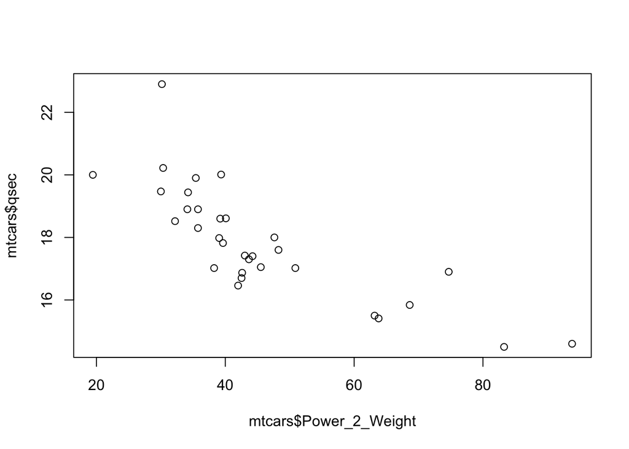

```r
plot(mtcars$Power_2_Weight,mtcars$qsec)
```

What hypothesis does the plot above address?

# Histograms are one way to look at distributions of values

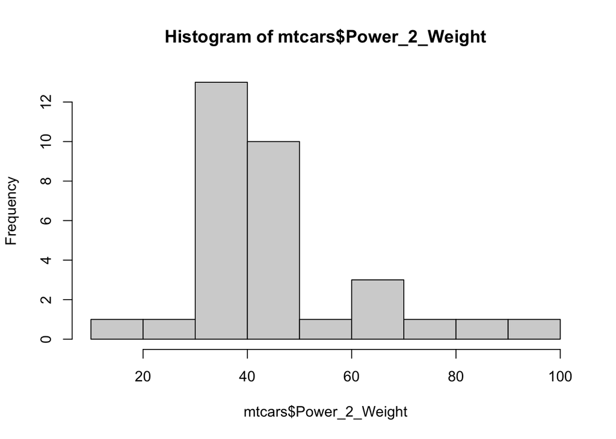

```r
hist(mtcars$Power_2_Weight)
```

# Question/Action

State a hypothesis about Power_2_Weight and mpg (miles per gallon). Create a graph that tests the hypothesis #the higher the mpg the higher the Power_2_Weight.

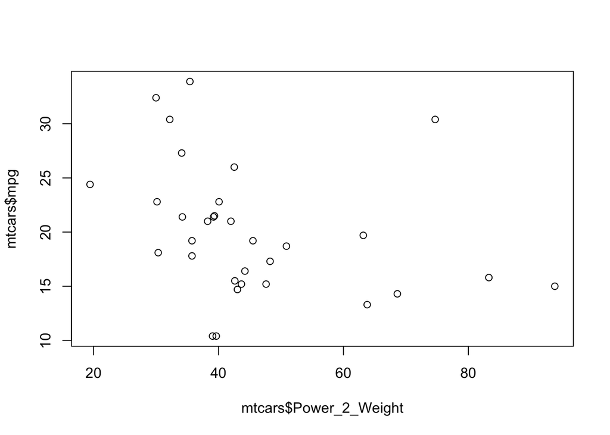

```r
plot(mtcars$Power_2_Weight,mtcars$mpg)
```

# forming Tables using Tapply

We can get various types of tables using tapply.

We specify the variable, one or more grouping variables and as statistics

Let’s look at mean mpg by number of cylinders

the command na.rm=TRUE at the end, removes any missing data before computing the mean

```r
tapply(mtcars$mpg,mtcars$cyl,FUN="mean", na.rm=TRUE)
```

```
##        4        6        8
## 26.66364 19.74286 15.10000
```

How about median hp by cyl and type of transmission am, so we have two groups

```r
tapply(mtcars$hp,INDEX=list(mtcars$cyl,mtcars$am), FUN="median")
```

```
##       0     1
## 4  95.0  78.5
## 6 116.5 110.0
## 8 180.0 299.5
```

if we want counts by grouping, we can use the table function

```r
table(mtcars$cyl)
```

```
##
##  4  6  8
## 11  7 14
```

We can use two groups

```r
table(mtcars$cyl, mtcars$am)
```

```
##
##      0  1
##   4  3  8
##   6  4  3
##   8 12  2
```

# Creating data frames in R

We can create data frames from within R in several ways

Lets declare some matched arrays, maybe describing some people

```r
last_name=c("Smith","Jones","Alvarez")
first_name=c("Bob","Jane","Angel")
age=c(30,27,32)
```

We can put these in a dataframe

```r
customer_df=data.frame(last=last_name, first=first_name,Age=age)
head(customer_df)
```

```
##      last first Age
## 1   Smith   Bob  30
## 2   Jones  Jane  27
## 3 Alvarez Angel  32
```

# Utilities

There are tools for reading data out of a csv (comma seperated value) or excel file and into a data frame, or to connect to a database and convert an SQL data table into a data frame.

There are also tools to write a data file to disk

It is often convenient to save results as data.frames, since they are easy to work with in other software packages if you save them as csv files

# Loading a DataFrame from a File

We need to specify the name of the file, with the file path included.

The easiest way to get the full file path correct is to use the file.choose() function to browse for the file.

Here, we browse for the file and save it to a variable called “infile”

One thing to be careful about is that file.choose() will not knit, use it in your work, but copy the file name to a variable and then “rem out” the file.choose() operation by putting # in front of it

We will use the Boston Assessment Roll again

```r
#rem this out by putting # in front of the command below

#file.choose()
```

```r
# cut and paste using Ctrl-C and Ctrl-V to assign the full path to infile

infile="/Users/katarinadouglas-blake/Downloads/Boston_Assessment_Roll_2024.csv"
```

now use read.csv() to load the assessment roll into a data frame

```r
boston_roll=read.csv(infile)
```

```r
head(boston_roll)
```

```
##   X_id       PID CM_ID    GIS_ID ST_NUM      ST_NAME UNIT_NUM        CITY
## 1    1 100001000    NA 100001000    104    PUTNAM ST          EAST BOSTON
## 2    2 100002000    NA 100002000    197 Lexington ST          EAST BOSTON
## 3    3 100003000    NA 100003000    199 Lexington ST          EAST BOSTON
## 4    4 100004000    NA 100004000    201 Lexington ST          EAST BOSTON
## 5    5 100005000    NA 100005000    203 Lexington ST          EAST BOSTON
## 6    6 100006000    NA 100006000    205 Lexington ST          EAST BOSTON
##   ZIP_CODE BLDG_SEQ NUM_BLDGS LUC LU            LU_DESC       BLDG_TYPE OWN_OCC
## 1     2128        1         1 105 R3 THREE-FAM DWELLING    RE - Row End       Y
## 2     2128        1         1 105 R3 THREE-FAM DWELLING RM - Row Middle       N
## 3     2128        1         1 105 R3 THREE-FAM DWELLING RM - Row Middle       Y
## 4     2128        1         1 105 R3 THREE-FAM DWELLING RM - Row Middle       N
## 5     2128        1         1 104 R2   TWO-FAM DWELLING    RE - Row End       Y
## 6     2128        1         1 105 R3 THREE-FAM DWELLING     DK - Decker       N
##                    OWNER MAIL_ADDRESSEE MAIL_STREET_ADDRESS   MAIL_CITY
```

[output cut: 69 more lines]

There are R functions to import excel files and many other types of data

Google “R import excel sheet” to learn how to do this

# Saving a dataframe to disk

This will let us use it somewhere else later

We do have to specify the whole path name, meaning the directory name plus the file name.

If you don’t specify a full path, R saves the file to the current directory

YOu can see the current directory in the Files window to the right in RStudio

you can see the current directory using getwd(), which means get working directory

```r
getwd()
```

```
## [1] "/Users/katarinadouglas-blake/Downloads"
```

You can change the directory using the “Session” menu in RStudio

```r
getwd()
```

```
## [1] "/Users/katarinadouglas-blake/Downloads"
```

Let’s save our customer_df data frame

specify the file name

```r
#I like to put the date in the name of an output file, it helps in long
#projects

outfile="customer_df_10_29_2024.csv"
```

```r
write.csv(customer_df,outfile)
```

Open this file in excel and see if it matches what you expect

# Lists

R can store things in lists, which can contain different types of objects

```r
a=list("Bob", 1, as.integer(2),TRUE,c(1,3,5,7,9))
```

Lists can store different types of things

We can index them

```r
a[1]
```

```
## [[1]]
## [1] "Bob"
```

we can assign names in a list as well

```r
a=list(name="Bob", purchases=1, category=as.integer(2),active=TRUE,items_purchased=c(1,3,5,7,9))
a
```

```
## $name
## [1] "Bob"
##
## $purchases
## [1] 1
##
## $category
## [1] 2
##
## $active
## [1] TRUE
##
## $items_purchased
## [1] 1 3 5 7 9
```

We can access these by name

```r
a$name
```

```
## [1] "Bob"
```

Notice that one of the things in a, items_purchased, is itself a vector.

You cannot store vector values within a single variable such as “items_purchased” in a data frame,

You can’t store this easily in a single SQL dataframe either

You can in a newer NOSQL database like MongoDB, or in a user defined class in R

More on that later….

We can’t really do math directly on a list, since they often have mixtures of data types in them.

Right now, dataframes will be more usefull to you

If you get working on complex problems, or start using NOSQL databases, you will be using lists more often.